# Loan Data from Prosper

## Introduction

The project aims at investigating the loan data from prosper.

## Preliminary Wrangling

```python
# import all packages and set plots to be embedded inline
import numpy as np
import pandas as pd
import matplotlib.pyplot as plt
import seaborn as sns

%matplotlib inline
```

This data set contains 113,937 loans with 81 feaatures on each loan, including loan amount, borrower rate (or interest rate), current loan status, borrower income, and many others. However, we will explore only a subset of these features as indicated below.

```python
loan_data=pd.read_csv('https://s3.amazonaws.com/udacity-hosted-downloads/ud651/prosperLoanData.csv')
loan_data.head()
```

|  | ListingKey | ListingNumber | ListingCreationDate | CreditGrade | Term | LoanStatus | ClosedDate | BorrowerAPR | BorrowerRate | LenderYield | ... | LP_ServiceFees | LP_CollectionFees | LP_GrossPrincipalLoss | LP_NetPrincipalLoss | LP_NonPrincipalRecoverypayments | PercentFunded | Recommendations | InvestmentFromFriendsCount | InvestmentFromFriendsAmount | Investors |
| --- | --- | --- | --- | --- | --- | --- | --- | --- | --- | --- | --- | --- | --- | --- | --- | --- | --- | --- | --- | --- | --- |
| 0 | 1021339766868145413AB3B | 193129 | 2007-08-26 19:09:29.263000000 | C | 36 | Completed | 2009-08-14 00:00:00 | 0.16516 | 0.1580 | 0.1380 | ... | -133.18 | 0.0 | 0.0 | 0.0 | 0.0 | 1.0 | 0 | 0 | 0.0 | 258 |
| 1 | 10273602499503308B223C1 | 1209647 | 2014-02-27 08:28:07.900000000 | NaN | 36 | Current | NaN | 0.12016 | 0.0920 | 0.0820 | ... | 0.00 | 0.0 | 0.0 | 0.0 | 0.0 | 1.0 | 0 | 0 | 0.0 | 1 |
| 2 | 0EE9337825851032864889A | 81716 | 2007-01-05 15:00:47.090000000 | HR | 36 | Completed | 2009-12-17 00:00:00 | 0.28269 | 0.2750 | 0.2400 | ... | -24.20 | 0.0 | 0.0 | 0.0 | 0.0 | 1.0 | 0 | 0 | 0.0 | 41 |
| 3 | 0EF5356002482715299901A | 658116 | 2012-10-22 11:02:35.010000000 | NaN | 36 | Current | NaN | 0.12528 | 0.0974 | 0.0874 | ... | -108.01 | 0.0 | 0.0 | 0.0 | 0.0 | 1.0 | 0 | 0 | 0.0 | 158 |
| 4 | 0F023589499656230C5E3E2 | 909464 | 2013-09-14 18:38:39.097000000 | NaN | 36 | Current | NaN | 0.24614 | 0.2085 | 0.1985 | ... | -60.27 | 0.0 | 0.0 | 0.0 | 0.0 | 1.0 | 0 | 0 | 0.0 | 20 |

5 rows × 81 columns

```python
loan_data.info()
```

```
<class 'pandas.core.frame.DataFrame'>
RangeIndex: 113937 entries, 0 to 113936
Data columns (total 81 columns):
ListingKey                             113937 non-null object
ListingNumber                          113937 non-null int64
ListingCreationDate                    113937 non-null object
CreditGrade                            28953 non-null object
Term                                   113937 non-null int64
LoanStatus                             113937 non-null object
ClosedDate                             55089 non-null object
BorrowerAPR                            113912 non-null float64
BorrowerRate                           113937 non-null float64
LenderYield                            113937 non-null float64
EstimatedEffectiveYield                84853 non-null float64
EstimatedLoss                          84853 non-null float64
EstimatedReturn                        84853 non-null float64
ProsperRating (numeric)                84853 non-null float64
ProsperRating (Alpha)                  84853 non-null object
ProsperScore                           84853 non-null float64
ListingCategory (numeric)              113937 non-null int64
BorrowerState                          108422 non-null object
Occupation                             110349 non-null object
EmploymentStatus                       111682 non-null object
EmploymentStatusDuration               106312 non-null float64
IsBorrowerHomeowner                    113937 non-null bool
CurrentlyInGroup                       113937 non-null bool
GroupKey                               13341 non-null object
DateCreditPulled                       113937 non-null object
CreditScoreRangeLower                  113346 non-null float64
CreditScoreRangeUpper                  113346 non-null float64
FirstRecordedCreditLine                113240 non-null object
CurrentCreditLines                     106333 non-null float64
OpenCreditLines                        106333 non-null float64
TotalCreditLinespast7years             113240 non-null float64
OpenRevolvingAccounts                  113937 non-null int64
OpenRevolvingMonthlyPayment            113937 non-null float64
InquiriesLast6Months                   113240 non-null float64
TotalInquiries                         112778 non-null float64
CurrentDelinquencies                   113240 non-null float64
AmountDelinquent                       106315 non-null float64
```

[output cut: 31 more lines]

```
LP_CustomerPayments                    113937 non-null float64
LP_CustomerPrincipalPayments           113937 non-null float64
LP_InterestandFees                     113937 non-null float64
LP_ServiceFees                         113937 non-null float64
LP_CollectionFees                      113937 non-null float64
LP_GrossPrincipalLoss                  113937 non-null float64
LP_NetPrincipalLoss                    113937 non-null float64
LP_NonPrincipalRecoverypayments        113937 non-null float64
PercentFunded                          113937 non-null float64
Recommendations                        113937 non-null int64
InvestmentFromFriendsCount             113937 non-null int64
InvestmentFromFriendsAmount            113937 non-null float64
Investors                              113937 non-null int64
dtypes: bool(3), float64(50), int64(11), object(17)
memory usage: 68.1+ MB
```

```python
loan_data.isna().sum()/loan_data.shape[0]
```

```
ListingKey                             0.000000
ListingNumber                          0.000000
ListingCreationDate                    0.000000
CreditGrade                            0.745886
Term                                   0.000000
LoanStatus                             0.000000
ClosedDate                             0.516496
BorrowerAPR                            0.000219
BorrowerRate                           0.000000
LenderYield                            0.000000
EstimatedEffectiveYield                0.255264
EstimatedLoss                          0.255264
EstimatedReturn                        0.255264
ProsperRating (numeric)                0.255264
ProsperRating (Alpha)                  0.255264
ProsperScore                           0.255264
ListingCategory (numeric)              0.000000
BorrowerState                          0.048404
Occupation                             0.031491
EmploymentStatus                       0.019792
EmploymentStatusDuration               0.066923
IsBorrowerHomeowner                    0.000000
CurrentlyInGroup                       0.000000
GroupKey                               0.882909
DateCreditPulled                       0.000000
CreditScoreRangeLower                  0.005187
CreditScoreRangeUpper                  0.005187
FirstRecordedCreditLine                0.006117
CurrentCreditLines                     0.066739
OpenCreditLines                        0.066739
                                         ...
TotalProsperLoans                      0.806165
TotalProsperPaymentsBilled             0.806165
OnTimeProsperPayments                  0.806165
ProsperPaymentsLessThanOneMonthLate    0.806165
ProsperPaymentsOneMonthPlusLate        0.806165
ProsperPrincipalBorrowed               0.806165
ProsperPrincipalOutstanding            0.806165
ScorexChangeAtTimeOfListing            0.833873
LoanCurrentDaysDelinquent              0.000000
LoanFirstDefaultedCycleNumber          0.851216
LoanMonthsSinceOrigination             0.000000
LoanNumber                             0.000000
LoanOriginalAmount                     0.000000
LoanOriginationDate                    0.000000
LoanOriginationQuarter                 0.000000
MemberKey                              0.000000
MonthlyLoanPayment                     0.000000
LP_CustomerPayments                    0.000000
LP_CustomerPrincipalPayments           0.000000
LP_InterestandFees                     0.000000
LP_ServiceFees                         0.000000
LP_CollectionFees                      0.000000
LP_GrossPrincipalLoss                  0.000000
LP_NetPrincipalLoss                    0.000000
LP_NonPrincipalRecoverypayments        0.000000
PercentFunded                          0.000000
Recommendations                        0.000000
InvestmentFromFriendsCount             0.000000
InvestmentFromFriendsAmount            0.000000
Investors                              0.000000
Length: 81, dtype: float64
```

```python
null_percent = (loan_data.isnull().sum() / loan_data.shape[0]) * 100

# Drop the columns with missing values greater than 10%
loan_data1 = loan_data.drop(columns=null_percent[null_percent > 10].index, axis=1)

# The resulting dataframe will only contain columns with missing values less than 10%
loan_data1.head()
```

|  | ListingKey | ListingNumber | ListingCreationDate | Term | LoanStatus | BorrowerAPR | BorrowerRate | LenderYield | ListingCategory (numeric) | BorrowerState | ... | LP_ServiceFees | LP_CollectionFees | LP_GrossPrincipalLoss | LP_NetPrincipalLoss | LP_NonPrincipalRecoverypayments | PercentFunded | Recommendations | InvestmentFromFriendsCount | InvestmentFromFriendsAmount | Investors |
| --- | --- | --- | --- | --- | --- | --- | --- | --- | --- | --- | --- | --- | --- | --- | --- | --- | --- | --- | --- | --- | --- |
| 0 | 1021339766868145413AB3B | 193129 | 2007-08-26 19:09:29.263000000 | 36 | Completed | 0.16516 | 0.1580 | 0.1380 | 0 | CO | ... | -133.18 | 0.0 | 0.0 | 0.0 | 0.0 | 1.0 | 0 | 0 | 0.0 | 258 |
| 1 | 10273602499503308B223C1 | 1209647 | 2014-02-27 08:28:07.900000000 | 36 | Current | 0.12016 | 0.0920 | 0.0820 | 2 | CO | ... | 0.00 | 0.0 | 0.0 | 0.0 | 0.0 | 1.0 | 0 | 0 | 0.0 | 1 |
| 2 | 0EE9337825851032864889A | 81716 | 2007-01-05 15:00:47.090000000 | 36 | Completed | 0.28269 | 0.2750 | 0.2400 | 0 | GA | ... | -24.20 | 0.0 | 0.0 | 0.0 | 0.0 | 1.0 | 0 | 0 | 0.0 | 41 |
| 3 | 0EF5356002482715299901A | 658116 | 2012-10-22 11:02:35.010000000 | 36 | Current | 0.12528 | 0.0974 | 0.0874 | 16 | GA | ... | -108.01 | 0.0 | 0.0 | 0.0 | 0.0 | 1.0 | 0 | 0 | 0.0 | 158 |
| 4 | 0F023589499656230C5E3E2 | 909464 | 2013-09-14 18:38:39.097000000 | 36 | Current | 0.24614 | 0.2085 | 0.1985 | 2 | MN | ... | -60.27 | 0.0 | 0.0 | 0.0 | 0.0 | 1.0 | 0 | 0 | 0.0 | 20 |

5 rows × 63 columns

```python
loan_data1.drop(columns=['ListingKey','ListingNumber'], inplace =True)
```

```python
loan_data1.dropna(inplace=True)
```

```python
loan_data1.reset_index(drop=True);
```

```python
loan_data1.columns, len(loan_data1.columns)
```

```
(Index(['ListingCreationDate', 'Term', 'LoanStatus', 'BorrowerAPR',
        'BorrowerRate', 'LenderYield', 'ListingCategory (numeric)',
        'BorrowerState', 'Occupation', 'EmploymentStatus',
        'EmploymentStatusDuration', 'IsBorrowerHomeowner', 'CurrentlyInGroup',
        'DateCreditPulled', 'CreditScoreRangeLower', 'CreditScoreRangeUpper',
        'FirstRecordedCreditLine', 'CurrentCreditLines', 'OpenCreditLines',
        'TotalCreditLinespast7years', 'OpenRevolvingAccounts',
        'OpenRevolvingMonthlyPayment', 'InquiriesLast6Months', 'TotalInquiries',
        'CurrentDelinquencies', 'AmountDelinquent', 'DelinquenciesLast7Years',
        'PublicRecordsLast10Years', 'PublicRecordsLast12Months',
        'RevolvingCreditBalance', 'BankcardUtilization',
        'AvailableBankcardCredit', 'TotalTrades',
        'TradesNeverDelinquent (percentage)', 'TradesOpenedLast6Months',
        'DebtToIncomeRatio', 'IncomeRange', 'IncomeVerifiable',
        'StatedMonthlyIncome', 'LoanKey', 'LoanCurrentDaysDelinquent',
        'LoanMonthsSinceOrigination', 'LoanNumber', 'LoanOriginalAmount',
        'LoanOriginationDate', 'LoanOriginationQuarter', 'MemberKey',
        'MonthlyLoanPayment', 'LP_CustomerPayments',
        'LP_CustomerPrincipalPayments', 'LP_InterestandFees', 'LP_ServiceFees',
        'LP_CollectionFees', 'LP_GrossPrincipalLoss', 'LP_NetPrincipalLoss',
        'LP_NonPrincipalRecoverypayments', 'PercentFunded', 'Recommendations',
        'InvestmentFromFriendsCount', 'InvestmentFromFriendsAmount',
        'Investors'],
       dtype='object'), 61)
```

```python
#to use
loan_data1=loan_data1[['IncomeRange','BorrowerAPR', 'BorrowerRate','AvailableBankcardCredit','TotalCreditLinespast7years', 'Occupation','LoanStatus','LoanOriginalAmount','CreditScoreRangeLower', 'CreditScoreRangeUpper','EmploymentStatus','IsBorrowerHomeowner','DebtToIncomeRatio','Investors','BorrowerState','EmploymentStatusDuration']]
```

```python
loan_data1.Occupation.value_counts(), len(loan_data1.Occupation.value_counts().index)
```

```
(Other                                 23334
 Professional                          12119
 Computer Programmer                    3909
 Executive                              3813
 Teacher                                3435
 Analyst                                3339
 Administrative Assistant               3329
 Accountant/CPA                         2900
 Clerical                               2719
 Sales - Commission                     2684
 Skilled Labor                          2457
 Nurse (RN)                             2385
 Retail Management                      2320
 Sales - Retail                         2219
 Police Officer/Correction Officer      1504
 Truck Driver                           1441
 Laborer                                1429
 Civil Service                          1384
 Construction                           1363
 Engineer - Mechanical                  1299
 Food Service Management                1115
 Military Enlisted                      1112
 Engineer - Electrical                  1039
 Medical Technician                     1025
 Food Service                            937
 Tradesman - Mechanic                    851
 Attorney                                834
 Social Worker                           679
 Postal Service                          587
 Professor                               513
                                       ...
 Military Officer                        317
 Bus Driver                              293
 Principal                               285
 Realtor                                 256
 Pharmacist                              244
 Teacher's Aide                          244
 Engineer - Chemical                     212
 Architect                               183
 Pilot - Private/Commercial              182
 Clergy                                  170
 Student - College Graduate Student      150
 Car Dealer                              141
 Chemist                                 137
 Biologist                               118
 Landscaping                             116
 Flight Attendant                        114
 Psychologist                            104
 Student - College Senior                103
 Religious                                94
 Tradesman - Plumber                      86
 Tradesman - Carpenter                    68
 Investor                                 66
 Student - College Junior                 60
 Dentist                                  54
 Homemaker                                40
 Student - College Sophomore              38
 Student - College Freshman               28
 Judge                                    22
 Student - Community College              14
 Student - Technical School                7
 Name: Occupation, Length: 67, dtype: int64, 67)
```

```python
loan_data1.Occupation.unique()
```

```
array(['Other', 'Professional', 'Skilled Labor', 'Executive',
       'Sales - Retail', 'Laborer', 'Food Service', 'Fireman',
       'Construction', 'Computer Programmer', 'Sales - Commission',
       'Retail Management', 'Engineer - Mechanical', 'Military Enlisted',
       'Clerical', 'Teacher', 'Clergy', 'Accountant/CPA', 'Attorney',
       'Nurse (RN)', 'Analyst', 'Flight Attendant', 'Nurse (LPN)',
       'Military Officer', 'Food Service Management',
       'Administrative Assistant', 'Police Officer/Correction Officer',
       'Social Worker', 'Truck Driver', 'Tradesman - Mechanic',
       'Medical Technician', 'Professor', 'Postal Service',
       'Waiter/Waitress', 'Civil Service', 'Pharmacist',
       'Tradesman - Electrician', 'Scientist', 'Dentist',
       'Engineer - Electrical', 'Landscaping', 'Tradesman - Carpenter',
       'Bus Driver', 'Tradesman - Plumber', 'Architect',
       'Engineer - Chemical', 'Doctor', 'Chemist',
       'Student - College Senior', "Teacher's Aide",
       'Pilot - Private/Commercial', "Nurse's Aide", 'Religious',
       'Homemaker', 'Student - College Graduate Student', 'Realtor',
       'Principal', 'Investor', 'Psychologist', 'Biologist',
       'Student - College Sophomore', 'Judge', 'Student - College Junior',
       'Car Dealer', 'Student - Community College',
       'Student - College Freshman', 'Student - Technical School'], dtype=object)
```

```python
def simplify_occupation(x):

    if x in ['Tradesman - Mechanic', 'Tradesman - Electrician', 'Tradesman - Carpenter', 'Tradesman - Plumber']:
        return 'Tradesman'
    elif x in ['Sales - Retail', 'Sales - Commission']:
        return 'Sales'
    elif x in ['Laborer', 'Construction']:
        return 'Laborer'
    elif x in ['Food Service', 'Waiter/Waitress']:
        return 'Food Service'
    elif x in ['Fireman', 'Police Officer/ Correction Officer', 'Military Enlisted', 'Military Officer']:
        return 'Fireman/Police/Military'
    elif x in ['Student - College Senior', 'Student - College Graduate Student',  'Student - College Sophomore', 'Student - College Junior', 'Student - Community College', 'Student - College Freshman', 'Student - Technical School']:
        return 'Student'
    else:
        return x

loan_data1['OccupationGroup'] = loan_data1['Occupation'].apply(simplify_occupation)
```

```python
loan_data1.OccupationGroup.value_counts(), len(loan_data1.OccupationGroup.value_counts().index)
```

```
(Other                                23334
 Professional                         12119
 Sales                                 4903
 Computer Programmer                   3909
 Executive                             3813
 Teacher                               3435
 Analyst                               3339
 Administrative Assistant              3329
 Accountant/CPA                        2900
 Laborer                               2792
 Clerical                              2719
 Skilled Labor                         2457
 Nurse (RN)                            2385
 Retail Management                     2320
 Fireman/Police/Military               1825
 Police Officer/Correction Officer     1504
 Tradesman                             1442
 Truck Driver                          1441
 Civil Service                         1384
 Engineer - Mechanical                 1299
 Food Service                          1295
 Food Service Management               1115
 Engineer - Electrical                 1039
 Medical Technician                    1025
 Attorney                               834
 Social Worker                          679
 Postal Service                         587
 Professor                              513
 Nurse (LPN)                            459
 Nurse's Aide                           422
 Doctor                                 414
 Student                                400
 Scientist                              337
 Bus Driver                             293
 Principal                              285
 Realtor                                256
 Pharmacist                             244
 Teacher's Aide                         244
 Engineer - Chemical                    212
 Architect                              183
 Pilot - Private/Commercial             182
 Clergy                                 170
 Car Dealer                             141
 Chemist                                137
 Biologist                              118
 Landscaping                            116
 Flight Attendant                       114
 Psychologist                           104
 Religious                               94
 Investor                                66
 Dentist                                 54
 Homemaker                               40
 Judge                                   22
 Name: OccupationGroup, dtype: int64, 53)
```

```python
loan_data1.to_csv('simple_data.csv',index= False)
```

```python
loan_data1.head()
```

|  | IncomeRange | BorrowerAPR | BorrowerRate | AvailableBankcardCredit | TotalCreditLinespast7years | Occupation | LoanStatus | LoanOriginalAmount | CreditScoreRangeLower | CreditScoreRangeUpper | EmploymentStatus | IsBorrowerHomeowner | DebtToIncomeRatio | Investors | BorrowerState | EmploymentStatusDuration | OccupationGroup |
| --- | --- | --- | --- | --- | --- | --- | --- | --- | --- | --- | --- | --- | --- | --- | --- | --- | --- |
| 0 | $25,000-49,999 | 0.16516 | 0.1580 | 1500.0 | 12.0 | Other | Completed | 9425 | 640.0 | 659.0 | Self-employed | True | 0.17 | 258 | CO | 2.0 | Other |
| 1 | $50,000-74,999 | 0.12016 | 0.0920 | 10266.0 | 29.0 | Professional | Current | 10000 | 680.0 | 699.0 | Employed | False | 0.18 | 1 | CO | 44.0 | Professional |
| 3 | $25,000-49,999 | 0.12528 | 0.0974 | 30754.0 | 29.0 | Skilled Labor | Current | 10000 | 800.0 | 819.0 | Employed | True | 0.15 | 158 | GA | 113.0 | Skilled Labor |
| 4 | $100,000+ | 0.24614 | 0.2085 | 695.0 | 49.0 | Executive | Current | 15000 | 680.0 | 699.0 | Employed | True | 0.26 | 20 | MN | 44.0 | Executive |
| 5 | $100,000+ | 0.15425 | 0.1314 | 86509.0 | 49.0 | Professional | Current | 15000 | 740.0 | 759.0 | Employed | True | 0.36 | 1 | NM | 82.0 | Professional |

### What is the structure of your dataset?

LoanOriginalAmount

### What features in the dataset do you think will help support your investigation into your feature(s) of interest?

EmploymentDuration,LoanStatus, Occupation, AvailableBankcardCredit, TotalCreditLinespast7years, BorrowerAPR, BorrowerState , IsBorrowerHomeowner, and IncomeRange may show some trends in relation to the original amount of loans.

## Univariate Exploration

Starting with the main feature of interest: LoanOriginalAmount

```python
def plot_sns_distplot(df,col, hist=True, kde=False,bins=None,xticks=False,
                      xticksrng=None, rotation=90,title=None,color=None,figsizex=10,figsizey=10 ):
    plt.figure(figsize=(figsizex,figsizey))
    sns.distplot(df[col],hist=hist, kde=kde,bins=bins)
    if xticks:
        plt.xticks( xticksrng,rotation=rotation)
    else:
        plt.xticks(rotation=rotation)
    plt.title(title)
    plt.show()

# def plot_sns_distplot(df,col, hist=True, kde=False,bins=None,xticks=False,
#                       xticksrng=None, rotation=90,title=None,color=None,figsizex=10,figsizey=10 ):
#     # Create a new figure with the specified size
#     plt.figure(figsize=(figsizex,figsizey))

#     # Plot a distribution plot using the specified column and parameters
#     sns.distplot(df[col],hist=hist, kde=kde,bins=bins)

#     # Check if xticks should be displayed and set them accordingly
#     if xticks:
#         plt.xticks( xticksrng,rotation=rotation)
#     else:
#         plt.xticks(rotation=rotation)

#     # Set a title for the plot if provided
#     plt.title(title)

#     # Show the plot
#     plt.show()
```

[figure not shown]

```python
# Plot the distribution of the 'LoanOriginalAmount' column from the 'loan_data1' DataFrame
plot_sns_distplot(loan_data1, 'LoanOriginalAmount',
                  title='Number of Borrowers Distribution over BorrowerAPR',bins=50,xticks=True,
                  xticksrng =np.arange(0, loan_data1['LoanOriginalAmount'].max()+1000,1000 ),figsizex=12, figsizey=7)
```

The destribution has a long tail, so we shall perform a log scale axis transformation.

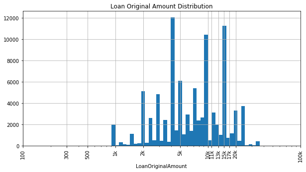

```python
log_binsize = 0.04
bins = 10 ** np.arange(2.4, np.log10(loan_data1['LoanOriginalAmount'].max())+log_binsize, log_binsize)

plt.figure(figsize=[10, 5])
# Plot a histogram of the 'LoanOriginalAmount' column using the specified bins
plt.hist(data =loan_data1, x = 'LoanOriginalAmount', bins = bins)
plt.xscale('log')
plt.xticks([100, 300,500, 1e3, 2e3, 5e3, 1e4, 1.1e4,1.3e4,1.5e4, 1.7e4, 2e4,  1e5], [100, 300, 500,
                                                                  '1k', '2k', '5k', '10k', '11k','13k','15k','17k', '20k','100k'],rotation=90)
plt.title('Loan Original Amount Distribution')
plt.grid()
plt.xlabel('LoanOriginalAmount')
plt.show()
```

The loan oridinal amount had a long tail so after transofrming the axis, we find pronounced peaks at the values between 4k-5k, 9k-10k, and at around 15k.

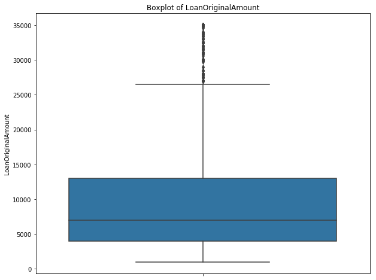

```python
# Create a new figure with a size of 10x8 inches
plt.figure(figsize=(10,8))

# Plot a boxplot of the 'LoanOriginalAmount' column
sns.boxplot(y='LoanOriginalAmount', data=loan_data1)

# Set the title of the plot
plt.title('Boxplot of LoanOriginalAmount')

# Display the plot
plt.show()
```

The IQR of the loan amount is between about 4k and 14k

```python
def plot_sns_countplot(df, x=None, y=None, rotation = 90, order=None,title=None,color=None,figsizex=10,figsizey=10):
    plt.figure(figsize=(figsizex,figsizey))
    sns.countplot(data = df, x=x, y=y, color = color, order=order)
    plt.xticks(rotation=rotation)
    plt.title(title)
    plt.show()
```

```python
loan_data1['IncomeRange'].value_counts().index
```

```
Index(['$50,000-74,999', '$25,000-49,999', '$100,000+', '$75,000-99,999',
       '$1-24,999', 'Not displayed', 'Not employed'],
      dtype='object')
```

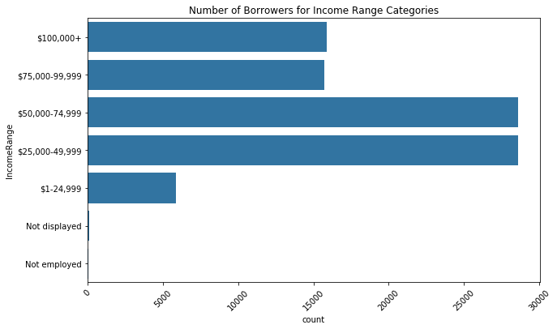

```python
# Set the base color for the plot
base_color = sns.color_palette()[0]

# Define the order of the income categories to be plotted
income_order = ['$100,000+', '$75,000-99,999', '$50,000-74,999', '$25,000-49,999',
                '$1-24,999', 'Not displayed', 'Not employed']

# Use the custom function 'plot_sns_countplot' to create a countplot of the 'IncomeRange' column
plot_sns_countplot(loan_data1, y='IncomeRange', color=base_color,
                   order=income_order, rotation=45, title='Number of Borrowers for Income Range Categories', figsizey=6)
```

The 2 most frequent income ranges are \$50k-74.999k and 25k-49.999k.

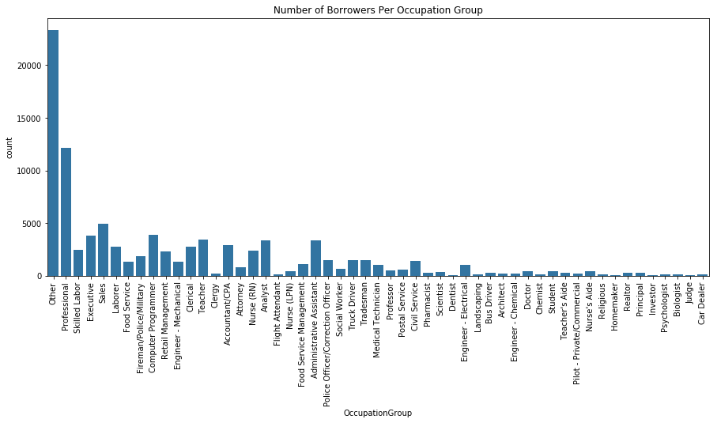

```python
# Use the custom function 'plot_sns_countplot' to create a countplot of the 'OccupationGroup' column
plot_sns_countplot(df=loan_data1,x='OccupationGroup',
                   color=base_color, figsizex=15,figsizey=6,
                   title='Number of Borrowers Per Occupation Group')
```

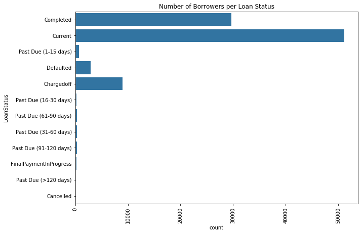

```python
# Use the custom function 'plot_sns_countplot' to create a countplot of the 'LoanStatus' column

plot_sns_countplot(df=loan_data1,y='LoanStatus',
                   color=base_color,title='Number of Borrowers per Loan Status',figsizey=7)
```

Most borrowers in this dataset have a current loan.

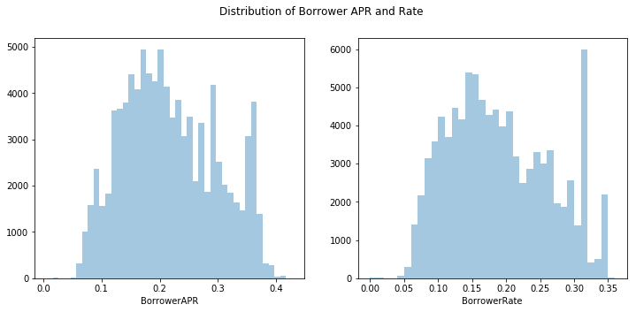

```python
# Set the figure size
plt.figure(figsize=(12,5))

# Create the first subplot
plt.subplot(1, 2, 1)

# Plot a histogram of 'BorrowerAPR' using Seaborn's 'distplot' function
sns.distplot(loan_data1['BorrowerAPR'], hist=True,
             bins=np.arange(loan_data1['BorrowerAPR'].min(),loan_data1['BorrowerAPR'].max()+.01,.01), kde=False)

# Create the second subplot
plt.subplot(1, 2, 2)

# Plot a histogram of 'BorrowerRate' using Seaborn's 'distplot' function
sns.distplot(loan_data1['BorrowerRate'], hist=True,
             bins=np.arange(loan_data1['BorrowerRate'].min(),loan_data1['BorrowerRate'].max()+.01,.01), kde=False)

# Set the title of the figure
plt.suptitle('Distribution of Borrower APR and Rate')

# Show the plot
plt.show()
```

It seems like there is a high correlation between the APR and Rate, we shall investigate that further in the bivariate analysis

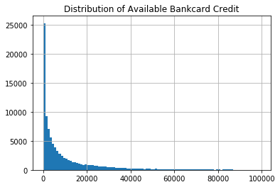

```python
# Plot histogram of AvailableBankcardCredit values with title

loan_data1['AvailableBankcardCredit'].hist(bins=np.arange(loan_data1['AvailableBankcardCredit'].min(),100000,1000))
plt.title("Distribution of Available Bankcard Credit")
plt.show()
```

The distribution of the AvailableBankcardCredit has a long tail and thus we will do axis transformation to logarithmic scale

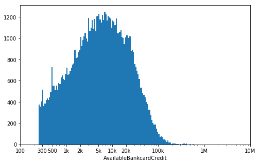

```python
# transforming the x-axis to log scale
log_binsize = 0.025
bins = 10 ** np.arange(2.4, np.log10(loan_data1['AvailableBankcardCredit'].max())+log_binsize, log_binsize)

plt.figure(figsize=[8, 5])
plt.hist(data =loan_data1, x = 'AvailableBankcardCredit', bins = bins)
plt.xscale('log')
plt.xticks([100, 300,500, 1e3, 2e3, 5e3, 1e4, 2e4, 1e5, 1e6, 1e7], [100, 300, 500,
                                                                    '1k', '2k', '5k', '10k', '20k','100k','1M','10M'])
plt.xlabel('AvailableBankcardCredit')
plt.show()
```

Only a small number of borrowers have larger than 100k available credit.

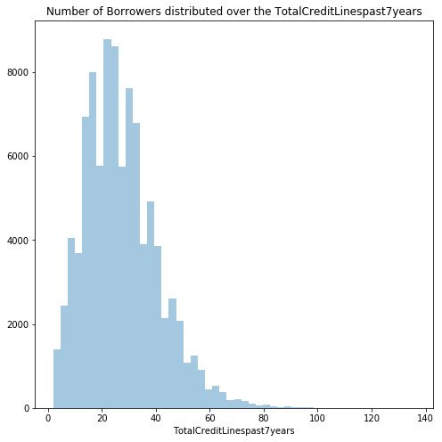

```python
plot_sns_distplot(loan_data1,'TotalCreditLinespast7years',
                  title='Number of Borrowers distributed over the TotalCreditLinespast7years',
                  rotation=0,figsizex=8,figsizey=8)
```

The distribution of the total credit lines in the past 7 years is right skewed.

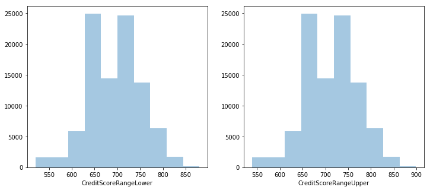

```python
plt.figure(figsize = [12, 5])


plt.subplot(1, 2, 1)
sns.distplot(loan_data1['CreditScoreRangeLower'], hist=True, bins=10, kde=False)


plt.subplot(1, 2, 2)
sns.distplot(loan_data1['CreditScoreRangeUpper'], hist=True, bins=10, kde=False)

plt.show()
```

Both credit score range limits seem correlated, we shall investigate this further in the bivariate analysis

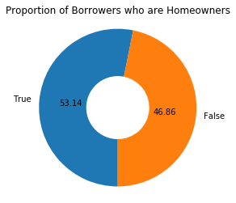

```python
# plot pie chart of IsBorrowerHomeowner values with percentages and custom formatting

# Calculate the value counts of the 'IsBorrowerHomeowner' column
sorted_counts = loan_data1['IsBorrowerHomeowner'].value_counts(normalize=True)

# Create a pie chart with custom formatting and set the figure size to a square shape
plt.pie(sorted_counts, labels = sorted_counts.index, autopct= '%.2f',startangle = -90,
        counterclock = False, wedgeprops = {'width' : 0.6});
plt.axis('square');

# Add a title to the plot
plt.title('Proportion of Borrowers who are Homeowners')

# Display the plot
plt.show()
```

53.14% of borrowers are home owners

```python
def percentage_blocks(df, var):
    """
    Take as input a dataframe and variable, and return a Pandas series with
    approximate percentage values for filling out a waffle plot.
    """
    # compute base quotas
    percentages = 100 * df[var].value_counts() / df.shape[0]
    counts = np.floor(percentages).astype(int) # integer part = minimum quota
    decimal = (percentages - counts).sort_values(ascending = False)

    # add in additional counts to reach 100
    rem = 100 - counts.sum()
    for cat in decimal.index[:rem]:
        counts[cat] += 1

    return counts
```

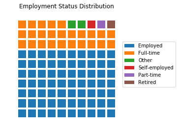

```python
waffle_counts = percentage_blocks(loan_data1, 'EmploymentStatus')

prev_count = 0
# for each category,
for cat in range(waffle_counts.shape[0]):
    # get the block indices
    blocks = np.arange(prev_count, prev_count + waffle_counts[cat])
    # and put a block at each index's location
    x = blocks % 10 # use mod operation to get ones digit
    y = blocks // 10 # use floor division to get tens digit
    plt.bar(x = x, height = 0.8, width = 0.8, bottom = y)
    prev_count += waffle_counts[cat]

# aesthetic wrangling
plt.legend(['Employed', 'Full-time', 'Other', 'Self-employed', 'Part-time', 'Retired'], bbox_to_anchor = (1, 0.5), loc = 6)
plt.axis('off');
plt.title('Employment Status Distribution');
plt.axis('square');
plt.show()
```

Around 70% are employe, 25% are full-time.

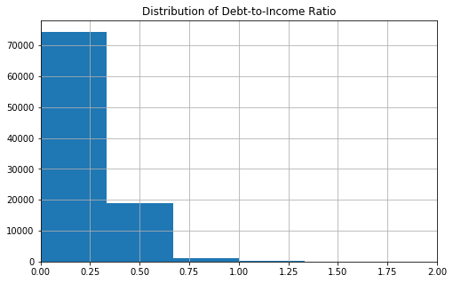

```python
# Plot histogram of DebtToIncomeRatio values with custom bin size and formatting

# Set the figure size
plt.figure(figsize=(8,5))

# Create a histogram of the 'DebtToIncomeRatio' column with custom bin size and color
loan_data1['DebtToIncomeRatio'].hist(bins=30, color=base_color)

# Set the x-axis limits to focus on the range of interest
plt.xlim([0,2])

# Add a title to the plot
plt.title('Distribution of Debt-to-Income Ratio')

# Display the plot
plt.show()
```

DebtToIncomeRatio has a long tail, we will transform the axis into logarithmic scale.

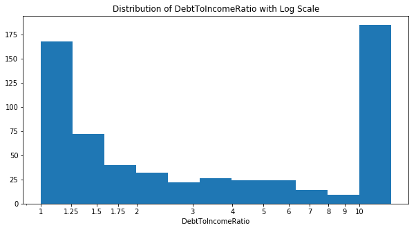

```python
# transforming the x-axis to log scale
log_binsize = 0.1
bins = 10 ** np.arange(0, np.log10(loan_data1['DebtToIncomeRatio'].max())+log_binsize, log_binsize)

plt.figure(figsize=[10, 5])
plt.hist(data =loan_data1, x = 'DebtToIncomeRatio', bins = bins)
plt.xscale('log')
plt.xticks([1, 1.25,1.5,1.75, 2,3,4,5,6,7,8,9,10], [1, 1.25,1.5,1.75, 2,3,4,5,6,7,8,9,10] )

plt.xlabel('DebtToIncomeRatio')
plt.title('Distribution of DebtToIncomeRatio with Log Scale')
plt.show()
```

Most debt to income ration is lower than 3, however there is a peak at 10+.

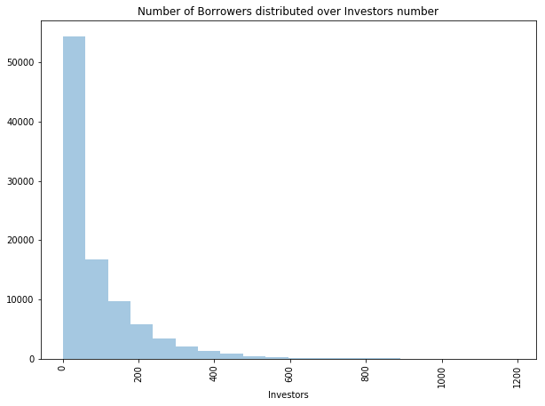

```python
# Call the custom function to generate the distribution plot of the 'Investors' column
plot_sns_distplot(loan_data1, 'Investors', bins=20, title='Number of Borrowers distributed over Investors number', figsizey=7)
```

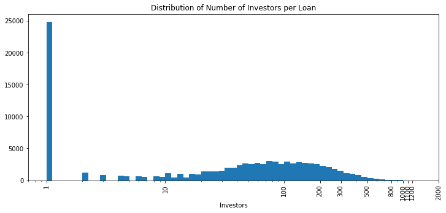

```python
# Create a histogram of Investors values with logarithmic scaling

# Define the bin size for the histogram
log_binsize = .05
bins = 10 ** np.arange(0, np.log10(loan_data1['Investors'].max())+log_binsize, log_binsize)

# Set the figure size
plt.figure(figsize=[12,5])

# Create a histogram of the 'Investors' column with custom bin size and logarithmic scaling
plt.hist(data =loan_data1, x = 'Investors', bins = bins)

# Set the x-axis scale to logarithmic
plt.xscale('log')

# Set custom tick marks and labels for the x-axis
plt.xticks([1, 10, 100, 200, 300, 500, 800, 1000, 1100, 1200, 2000],
           [1, 10, 100, 200, 300, 500, 800, 1000, 1100, 1200, 2000],
           rotation = 90)

# Set the x-axis label
plt.xlabel('Investors')

# Add a title to the plot
plt.title('Distribution of Number of Investors per Loan')

# Display the plot
plt.show()
```

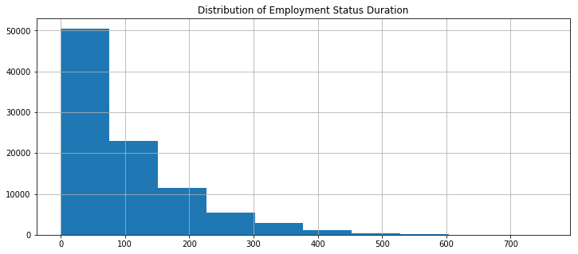

```python
# Create a histogram of the EmploymentStatusDuration column

# Set the figure size
plt.figure(figsize=[12,5])

# Create a histogram of the 'EmploymentStatusDuration' column with default bin size
loan_data1['EmploymentStatusDuration'].hist()

# Add a title to the plot
plt.title('Distribution of Employment Status Duration')

# Display the plot
plt.show()
```

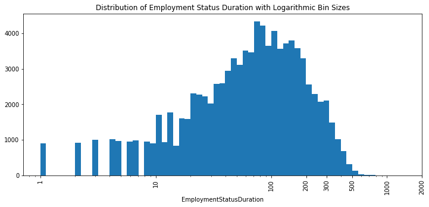

```python
# Create a histogram of the EmploymentStatusDuration column with logarithmic bin sizes

# Set the log bin size and bins
log_binsize = .05
bins = 10 ** np.arange(0, np.log10(loan_data1['EmploymentStatusDuration'].max())+log_binsize, log_binsize)

# Set the figure size
plt.figure(figsize=[12,5])

# Create a histogram of the 'EmploymentStatusDuration' column with logarithmic bin sizes
plt.hist(data=loan_data1, x='EmploymentStatusDuration', bins=bins)

# Set the x-axis to log scale
plt.xscale('log')

# Set the x-ticks to display in log scale with the specified values
plt.xticks([1, 10, 100,200,300,500,1000,2000], [1, 10, 100,200,300,500,1000,2000], rotation = 90)

# Add a label to the x-axis
plt.xlabel('EmploymentStatusDuration')

# Add a title to the plot
plt.title('Distribution of Employment Status Duration with Logarithmic Bin Sizes')

# Display the plot
plt.show()
```

The majority have employment duration between 50-200 weeks.

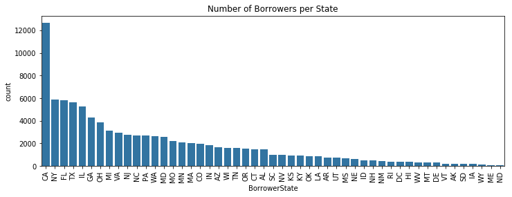

```python
# Create a list of states, sorted in descending order of the number of borrowers in each state
state_order = loan_data1['BorrowerState'].value_counts().index

# Create a seaborn countplot to visualize the number of borrowers per state
plot_sns_countplot(loan_data1, x= 'BorrowerState', color=base_color, order =state_order,
                   title='Number of Borrowers per State',figsizex=12,figsizey=4)
```

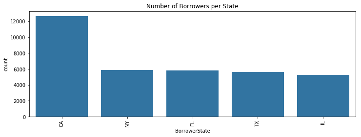

```python
# Create a seaborn countplot to visualize the number of borrowers per state for the top 5 states only
plot_sns_countplot(loan_data1, x= 'BorrowerState', color=base_color, order =state_order[0:5],
                   title='Number of Borrowers per State',figsizex=12,figsizey=4)
```

The top 5 states in the number of borrowers are CA,NY, FL, TX, and IL.

```python
loan_data1.info()
```

```
<class 'pandas.core.frame.DataFrame'>
Int64Index: 94843 entries, 0 to 113936
Data columns (total 17 columns):
IncomeRange                   94843 non-null object
BorrowerAPR                   94843 non-null float64
BorrowerRate                  94843 non-null float64
AvailableBankcardCredit       94843 non-null float64
TotalCreditLinespast7years    94843 non-null float64
Occupation                    94843 non-null object
LoanStatus                    94843 non-null object
LoanOriginalAmount            94843 non-null int64
CreditScoreRangeLower         94843 non-null float64
CreditScoreRangeUpper         94843 non-null float64
EmploymentStatus              94843 non-null object
IsBorrowerHomeowner           94843 non-null bool
DebtToIncomeRatio             94843 non-null float64
Investors                     94843 non-null int64
BorrowerState                 94843 non-null object
EmploymentStatusDuration      94843 non-null float64
OccupationGroup               94843 non-null object
dtypes: bool(1), float64(8), int64(2), object(6)
memory usage: 14.9+ MB
```

### Discuss the distribution(s) of your variable(s) of interest. Were there any unusual points? Did you need to perform any transformations?

The distributions for the following features had long tails, and log scale transformations were performed on the axis: LoanOriginalAmount, AvailableBankcardCredit, EmploymentStatusDuration, Investors, and DebtToIncomeRatio.

### Of the features you investigated, were there any unusual distributions? Did you perform any operations on the data to tidy, adjust, or change the form of the data? If so, why did you do this?

The number of investors had a distinct behavior, the peak that has the highest count is at 1 investor, and the remaining range had a somewhat normal distribution with a wide standrd deviation.

In order to make the data more comprhensible, the occupations were grouped according the main major field of work to reduce the number of categories.

## Bivariate Exploration

Now, we investigate relationships between pairs of variables.

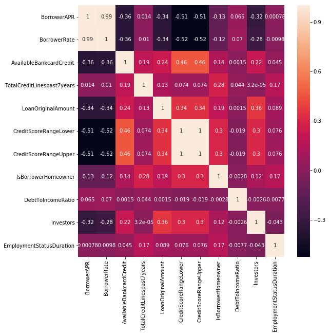

```python
plt.figure(figsize=(9,9))
sns.heatmap(loan_data1.corr(), annot=True)
plt.show()
```

As we suspected in the univariate analysis, both BorrowerAPR and BorrowerRate, and CreditScoreRangeLower and CreditScoreRangeUpper are correlated up to 0.98 and 1. We shall engineer features for the credit score ranges which is the ratio between the lower and upper. We shall use only the BorrowerAPR in our investigations later.

```python
loan_data1['CreditScoreLowerToUpperRatio'] = loan_data1['CreditScoreRangeLower']/loan_data1['CreditScoreRangeUpper']
```

We also plot the pairplot between every pair of features.

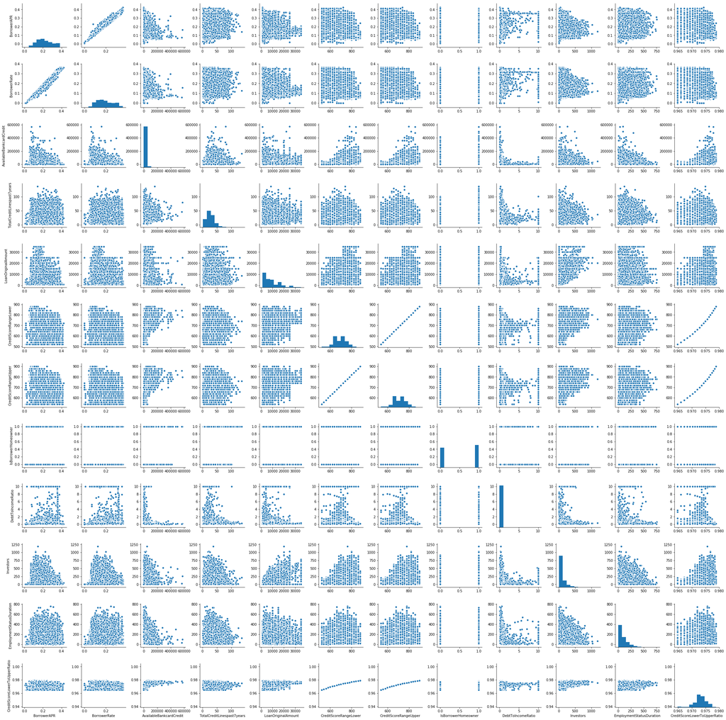

```python
plt.figure(figsize=(10,10))
sns.pairplot(loan_data1);
plt.show()
```

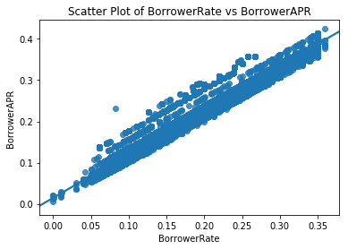

```python
# Plot the scatter plot
sns.regplot(x='BorrowerRate', y='BorrowerAPR', data=loan_data1)

# Add labels and title
plt.xlabel("BorrowerRate")
plt.ylabel("BorrowerAPR")
plt.title("Scatter Plot of BorrowerRate vs BorrowerAPR")

# Show the plot
plt.show()
```

This further confirms the correlation between borrower apr and rate.

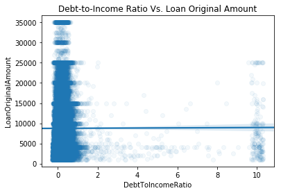

```python
# Create a scatter plot with a linear regression line showing the relationship between debt-to-income ratio and loan original amount
sns.regplot(data = loan_data1, x = 'DebtToIncomeRatio', y = 'LoanOriginalAmount', truncate=False, x_jitter=0.3, scatter_kws={'alpha':1/20});
# Add a title to the plot
plt.title('Debt-to-Income Ratio Vs. Loan Original Amount')
plt.show()
```

To investigate the debt to income ratio against the loan original amount weplot reg plot but things are not clear, we further investigate using hist2d.

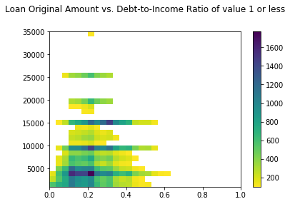

```python
# Create a 2D histogram (heatmap) of loan original amount vs. debt-to-income ratio for borrowers with a debt-to-income ratio of 1 or less

plt.hist2d(data = loan_data1[loan_data1['DebtToIncomeRatio']<=1], x = 'DebtToIncomeRatio', y = 'LoanOriginalAmount', cmin=100, cmap='viridis_r',bins=30)
plt.colorbar()
# Add a title to the plot
plt.title('Loan Original Amount vs. Debt-to-Income Ratio of value 1 or less',y=1.1)
plt.show()
```

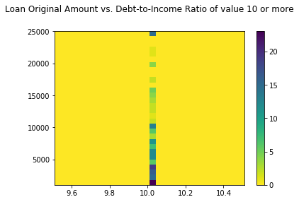

```python
# Create a 2D histogram (heatmap) of loan original amount vs. debt-to-income ratio for borrowers with a debt-to-income ratio of 10 or more

plt.hist2d(data = loan_data1[loan_data1['DebtToIncomeRatio']>=10], x = 'DebtToIncomeRatio', y = 'LoanOriginalAmount', cmap='viridis_r',bins=30)
plt.colorbar()
plt.title('Loan Original Amount vs. Debt-to-Income Ratio of value 10 or more',y=1.1)
plt.show()
```

A small number of borrowers had a debt to income ration greater than 10, most loans are between 0-10k.

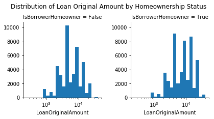

```python
# Set the logarithmic bin size and create a logarithmic bin range
log_binsize = 0.1
bins = 10 ** np.arange(2.4, np.log10(loan_data1['LoanOriginalAmount'].max()) + log_binsize, log_binsize)

# Create a FacetGrid with one column for borrowers who are homeowners and one column for borrowers who are not homeowners
g = sns.FacetGrid(data=loan_data1, col='IsBorrowerHomeowner')

# Map a histogram onto each column of the FacetGrid, with loan original amount on the x-axis and the logarithmic bin range on the y-axis
g.map(plt.hist, 'LoanOriginalAmount', bins=bins).set(xscale='log')

# Add a title to the plot
plt.suptitle('Distribution of Loan Original Amount by Homeownership Status',y=1.05)

# Show the plot
plt.show()
```

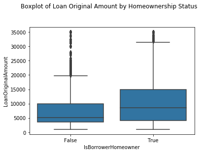

```python
# Create a boxplot of loan original amount by homeownership status
sns.boxplot(data=loan_data1, x='IsBorrowerHomeowner', y='LoanOriginalAmount', color=base_color)
# Add a title to the plot
plt.suptitle('Boxplot of Loan Original Amount by Homeownership Status',y=1.05)
plt.show()
```

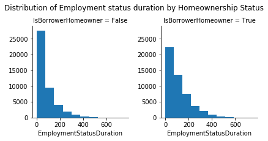

```python
g = sns.FacetGrid(data = loan_data1, col = 'IsBorrowerHomeowner')
g.map(plt.hist, 'EmploymentStatusDuration')
# Add a title to the plot
plt.suptitle('Distribution of Employment status duration by Homeownership Status',y=1.05)
plt.show()
```